# Random Forest Model on CarSpecs Dataset

```r
set.seed(123)

#remove stored variables and data in environment
rm(list=ls())

#load in libraries
suppressPackageStartupMessages({
library(dplyr)
library(glue)
library(knitr)
library(broom)
library(stargazer)
})
```

```r
load("CarSpecs.RData")

#standard linear regression model

# model1 <- lm(formula = msrp_2019 ~ epa_class + drive_train + passenger_capacity + doors + wheelbase + height + fuel_tank_cap + city_mpg + hwy_mpg + net_torque + fuel_system + engine_type + net_hp + transmit_descr + brake_type + steer_type, data = carspecs)

# summary(model1)
# plot(model1)
```

```r
#import randomForest package
suppressPackageStartupMessages(library(randomForest))
if (!require(randomForest)) install.packages("randomForest")
library(randomForest)
```

```r
#same formula as the one used for a linear regression model
reg_formula <- msrp_2019 ~ epa_class + drive_train + passenger_capacity + doors + wheelbase + height + fuel_tank_cap + city_mpg + hwy_mpg + net_torque + fuel_system + engine_type + net_hp + transmit_descr + brake_type + steer_type


# Grow the random tree and set the number of predictors to consider at each split of the tree (numpred)

numpred <- 5
randomForest_Model <- randomForest(formula = reg_formula, data = carspecs, mtry = numpred, importance = TRUE)

#Summary of the random forest model
randomForest_Model
```

```
Call:
 randomForest(formula = reg_formula, data = carspecs, mtry = numpred,      importance = TRUE)
               Type of random forest: regression
                     Number of trees: 500
No. of variables tried at each split: 5

          Mean of squared residuals: 38034688
                    % Var explained: 98.48
```

As seen from the summary above, the random forest model created 500 trees with 5 variables at every split.

```r
kable(importance(randomForest_Model), caption = "Importance of each variable in the random forest model")
```

Importance of each variable in the random forest model

|  | %IncMSE | IncNodePurity |
| --- | --- | --- |
| epa_class | 16.033561 | 1.033306e+11 |
| drive_train | 14.978304 | 8.010546e+10 |
| passenger_capacity | 13.001065 | 1.069603e+11 |
| doors | 8.623689 | 5.524344e+10 |
| wheelbase | 22.347834 | 7.435746e+11 |
| height | 29.924927 | 6.465352e+11 |
| fuel_tank_cap | 25.451309 | 7.903046e+11 |
| city_mpg | 17.975787 | 2.122229e+12 |
| hwy_mpg | 11.207247 | 9.507428e+11 |
| net_torque | 18.356806 | 2.728318e+12 |
| fuel_system | 10.576478 | 3.554191e+10 |
| engine_type | 28.511748 | 8.551796e+11 |
| net_hp | 23.106134 | 2.796670e+12 |
| transmit_descr | 15.837463 | 3.260367e+10 |
| brake_type | 10.798021 | 3.606387e+10 |
| steer_type | 15.593047 | 1.500032e+09 |

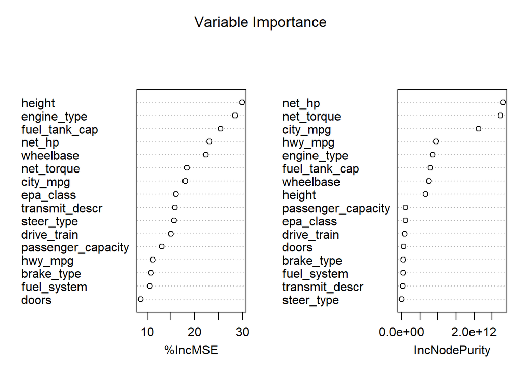

```r
varImpPlot(randomForest_Model, main = "Variable Importance")
```

`%IncMSE` is the amount that the MSE of predictions increases if the variable is randomly chosen instead of using its actual value which is how important it is for prediction. `IncNodePurity` measures how much splitting on it improves the “purity” (the similarity of the data points in each leaf). In both metrics, higher values mean it’s more important.

From the graph above, predictors like engine_type, height, fuel_tank_cap, net_hp, and wheelbase seem to be the most important. On the other hand, predictors like doors, steer_type, and fuel_system don’t seem to as important in the regression models.

```r
preds2 <- predict(randomForest_Model)

SSE2 <- sum((preds2 - carspecs$msrp_2019)^2)
SST2 <- sum((carspecs$msrp_2019 - mean(carspecs$msrp_2019))^2)

R_sq2 <- 1 - SSE2/SST2

glue("Random forest trees with all data as training:-

      SSE: {round(SSE2, digits = 3)}
      SST: {round(SST2, digits = 3)}
      R-squared: {round(R_sq2, digits = 3)}")
```

```
Random forest trees with all data as training:-

SSE: 184886616535.541
SST: 12203189957720.9
R-squared: 0.985
```

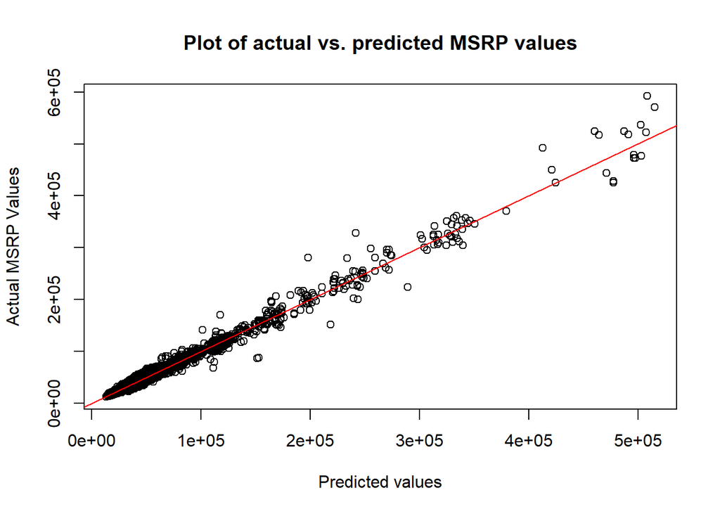

```r
plot(preds2, carspecs$msrp_2019, main = "Plot of actual vs. predicted MSRP values", xlab = "Predicted values", ylab = "Actual MSRP Values")
abline(0,1, col = "red")
```

The model has an R squared value of 98.5% which seems to be extremely high. This might be due to overfitting to the data since the predictions are on the same data set that the model was trained on.

I can try to split the data into training and testing sets to better evaluate the regression models.

```r
# Split the data into training and testing sets
indices <- sample(nrow(carspecs))
n_train <- round(0.7 * nrow(carspecs))

training_data <- carspecs[indices[1:n_train], ]
testing_data <- carspecs[indices[(n_train + 1):nrow(carspecs)], ]
```

```r
ranFor_cv <- randomForest(reg_formula, data = training_data, importance = TRUE)
preds3 <- predict(ranFor_cv, testing_data)

SSE3 <- sum((preds3 - testing_data$msrp_2019)^2)
SST3 <- sum((testing_data$msrp_2019 - mean(testing_data$msrp_2019))^2)

R_sq3 <- 1 - SSE3/SST3

glue("Random forest trees with 70% of data as training and 30% as testing:-

      SSE: {round(SSE3, digits = 3)}
      SST: {round(SST3, digits = 3)}
      R-squared: {round(R_sq3, digits = 3)}")
```

```
Random forest trees with 70% of data as training and 30% as testing:-

SSE: 125903012738.939
SST: 4809819660370.37
R-squared: 0.974
```

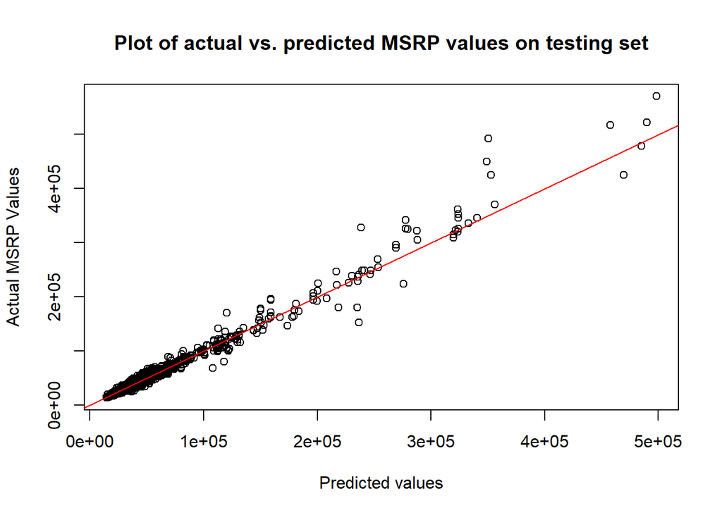

```r
plot(preds3, carspecs$msrp_2019[indices[(n_train + 1):nrow(carspecs)]], main = "Plot of actual vs. predicted MSRP values on testing set", xlab = "Predicted values", ylab = "Actual MSRP Values")
abline(0,1, col = "red")
```